# Evaluation: From precision, recall, and F-measure to ROC, informedness, markedness and correlation

Krishna Kalyan

# About the Author

[figure not shown]

# Introduction

- Contingency table

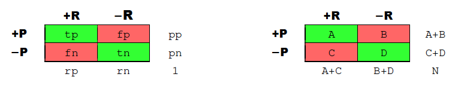

- Measure to evaluate Machine Learning System
1. Precision
2. Recall
3. F Measure
4. Issues with them
- Alternate Techniques
1. Accuracy
2. Cohen Kappa

# ROC Analysis

- ROC analysis give geometric insights into the nature of the measures and their sensitivity to skew
- Compare Classifiers
- Choose parameters based on maximization of AUC

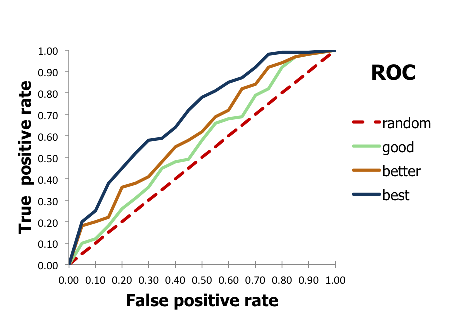

# Informedness and Markedness

- Markedness

Markedness quantifies how marked a condition is for the specified predictor, and specifies the probability that a condition is marked by the predictor (versus chance).

Markedness is a deep measure of how consistently the outcome has the Predictor as a Marker by combining surface measures about what proportion of Predictions are correct

Precision + Inverse Precision - $1$

- Informedness

Informedness quantifies how informed a predictor is for the specified condition, and specifies the probability that a prediction is informed in relation to the condition (versus chance).

Informedness is a deep measure of how consistently the predictor predicts the outcome by combining surface measures about what proportion of outcomes are correctly predicted.

Recall + Inverse Recall - $1$

# Regression

- Linear Regression
- Estimating Coefficients
1. Rp
2. Rr
3. Rg

# Conclusion

Infromedness usually is a better evaluation measure in binary classification.

Further work to research into the multiclass application of the technique.

Explore the relationship between Infromedness and Markedness

We have a better and a more intuitive understanding of the mearues that we could use for evaluating our ML system.

- Accuracy
- Cohen Kappa
- Precision
- Recall
- F1-Score
- Bookmaker Informedness / Delta P’
- Markedness

# Skipped

- Significance
- Montecarlo Simulation
- Evenness (Used in multiclass problems)